# Exercise 15.3

Manuela Giansante

2022-12-01

```r
library(data.table) #to read the data
library(naniar) # missing values
library(caret)  # to partition the data
library(kableExtra) # tables
library(cluster)
library(factoextra) #hcut function
library(tidyr) # gather()
library(dplyr) # select()
library(FNN)
```

```r
df <- fread("Cereals.csv")
df<- data.frame(df)
str(df) # structure
```

```
## 'data.frame':    77 obs. of  16 variables:
##  $ name    : chr  "100%_Bran" "100%_Natural_Bran" "All-Bran" "All-Bran_with_Extra_Fiber" ...
##  $ mfr     : chr  "N" "Q" "K" "K" ...
##  $ type    : chr  "C" "C" "C" "C" ...
##  $ calories: int  70 120 70 50 110 110 110 130 90 90 ...
##  $ protein : int  4 3 4 4 2 2 2 3 2 3 ...
##  $ fat     : int  1 5 1 0 2 2 0 2 1 0 ...
##  $ sodium  : int  130 15 260 140 200 180 125 210 200 210 ...
##  $ fiber   : num  10 2 9 14 1 1.5 1 2 4 5 ...
##  $ carbo   : num  5 8 7 8 14 10.5 11 18 15 13 ...
##  $ sugars  : int  6 8 5 0 8 10 14 8 6 5 ...
##  $ potass  : int  280 135 320 330 NA 70 30 100 125 190 ...
##  $ vitamins: int  25 0 25 25 25 25 25 25 25 25 ...
##  $ shelf   : int  3 3 3 3 3 1 2 3 1 3 ...
##  $ weight  : num  1 1 1 1 1 1 1 1.33 1 1 ...
##  $ cups    : num  0.33 1 0.33 0.5 0.75 0.75 1 0.75 0.67 0.67 ...
##  $ rating  : num  68.4 34 59.4 93.7 34.4 ...
```

```r
summary(df) #summary
```

```
##      name               mfr                type              calories
##  Length:77          Length:77          Length:77          Min.   : 50.0
##  Class :character   Class :character   Class :character   1st Qu.:100.0
##  Mode  :character   Mode  :character   Mode  :character   Median :110.0
##                                                           Mean   :106.9
##                                                           3rd Qu.:110.0
##                                                           Max.   :160.0
##
##     protein           fat            sodium          fiber
##  Min.   :1.000   Min.   :0.000   Min.   :  0.0   Min.   : 0.000
##  1st Qu.:2.000   1st Qu.:0.000   1st Qu.:130.0   1st Qu.: 1.000
##  Median :3.000   Median :1.000   Median :180.0   Median : 2.000
##  Mean   :2.545   Mean   :1.013   Mean   :159.7   Mean   : 2.152
##  3rd Qu.:3.000   3rd Qu.:2.000   3rd Qu.:210.0   3rd Qu.: 3.000
##  Max.   :6.000   Max.   :5.000   Max.   :320.0   Max.   :14.000
##
##      carbo          sugars           potass          vitamins
##  Min.   : 5.0   Min.   : 0.000   Min.   : 15.00   Min.   :  0.00
##  1st Qu.:12.0   1st Qu.: 3.000   1st Qu.: 42.50   1st Qu.: 25.00
##  Median :14.5   Median : 7.000   Median : 90.00   Median : 25.00
##  Mean   :14.8   Mean   : 7.026   Mean   : 98.67   Mean   : 28.25
##  3rd Qu.:17.0   3rd Qu.:11.000   3rd Qu.:120.00   3rd Qu.: 25.00
##  Max.   :23.0   Max.   :15.000   Max.   :330.00   Max.   :100.00
##  NA's   :1      NA's   :1        NA's   :2
##      shelf           weight          cups           rating
##  Min.   :1.000   Min.   :0.50   Min.   :0.250   Min.   :18.04
##  1st Qu.:1.000   1st Qu.:1.00   1st Qu.:0.670   1st Qu.:33.17
##  Median :2.000   Median :1.00   Median :0.750   Median :40.40
##  Mean   :2.208   Mean   :1.03   Mean   :0.821   Mean   :42.67
##  3rd Qu.:3.000   3rd Qu.:1.00   3rd Qu.:1.000   3rd Qu.:50.83
##  Max.   :3.000   Max.   :1.50   Max.   :1.500   Max.   :93.70
##
```

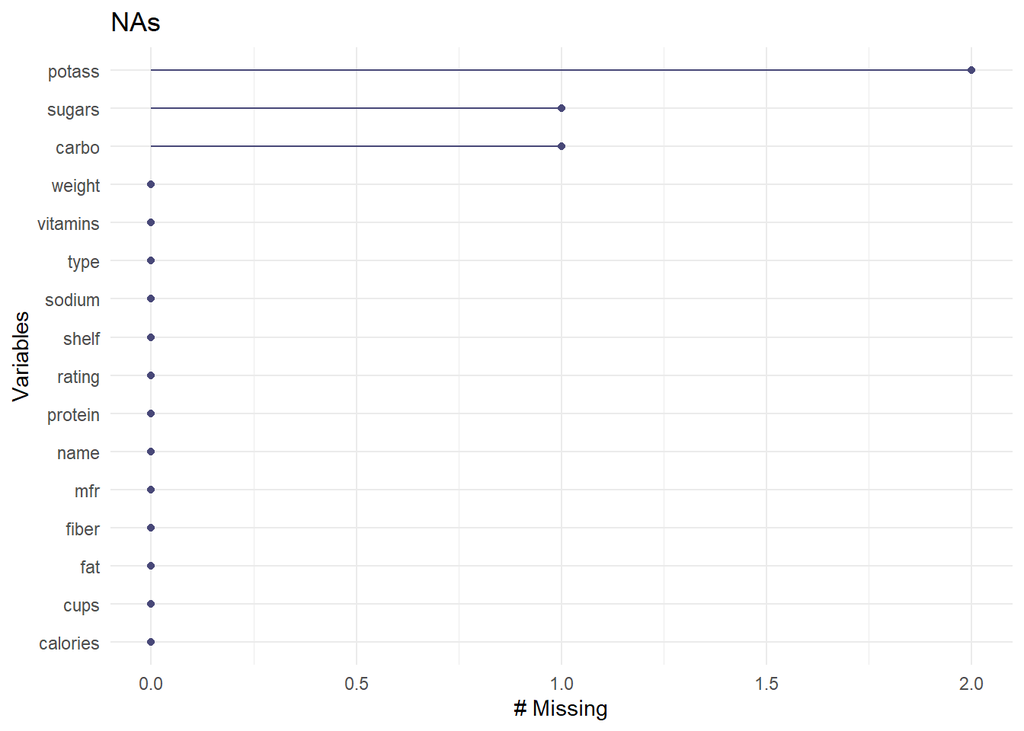

```r
gg_miss_var(df) + ggtitle("NAs") #missing values analysis
```

```r
df<- na.omit(df) # remove missing values

df2<- df[,-c(1,2,3,13)] # remove categorical variables
```

We have 4 missing values, 1 each for sugars and carbo and 2 for potassium. We omit them. We remove categorical variables, we only keep those variables that describe the nutritional values, cups and rating.

### Hierarchical Clustering:

### 15.3.a

The data needs to be pre-processed with range (normalised) because clustering method is based on Euclidian distances, metrics are important. we cluster through single and complete linkage. The former implies that in the agglomerative process, we are utilising the minimum distance (the distance between the closest records of 2 clusters), this method might cluster together records that are not actually close to one another. The latter, instead uses the maximum distance. It clusters data points at the start that are not that distant from each other. The similarity of any of the two cluster is the similarity of their most dissimilar pair.

```r
values<- preProcess(df2, method=c("range"))  # building values for normalisation
normal.df <- predict(values, df2) # normalise the data

row.names(normal.df)<- df$name
head(row.names(normal.df))
```

```
## [1] "100%_Bran"                 "100%_Natural_Bran"
## [3] "All-Bran"                  "All-Bran_with_Extra_Fiber"
## [5] "Apple_Cinnamon_Cheerios"   "Apple_Jacks"
```

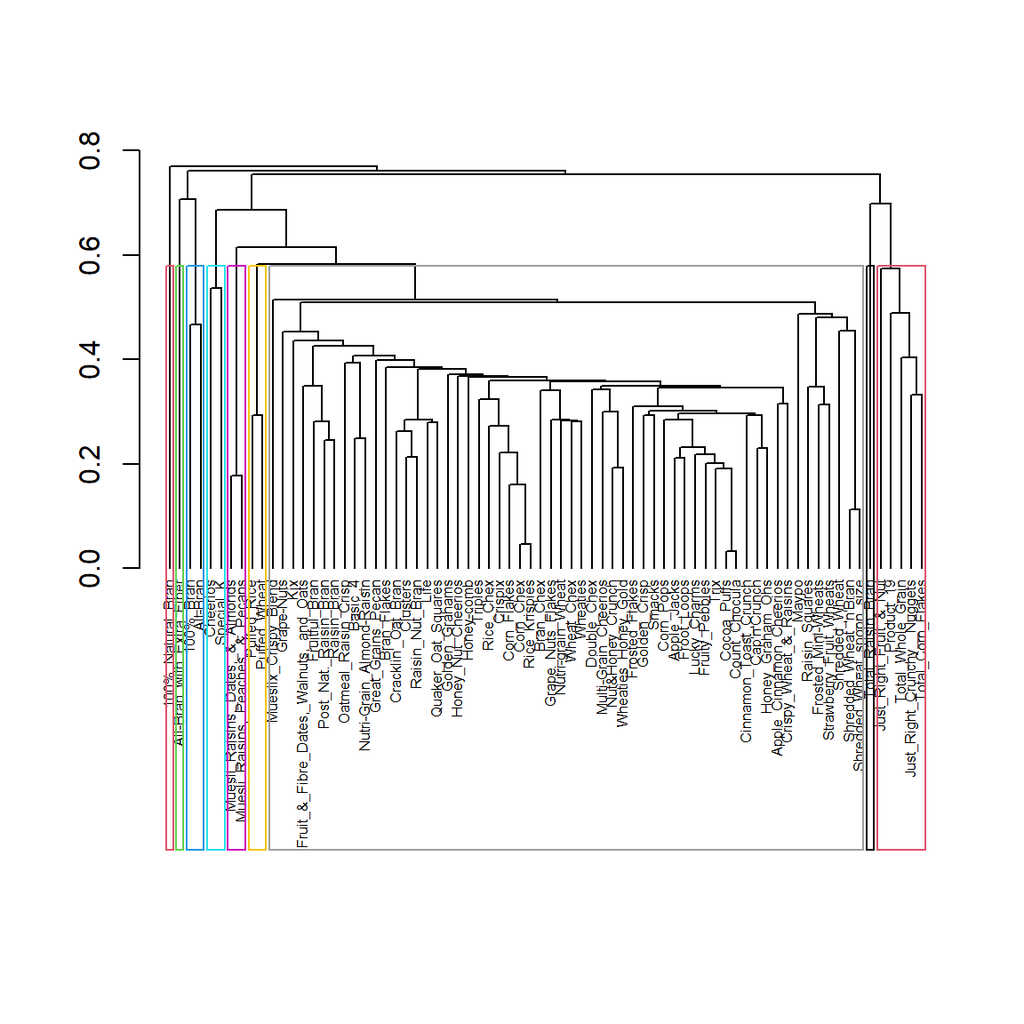

```r
# compute normalized distance
d.norm<- dist(normal.df, method = "euclidean") # table 15.4

hc1<- hclust(d.norm, method = "single") # single linkage
plot(hc1, hang=-1,ann= FALSE,cex=0.5) # plotting clustering
rect.hclust(hc1, k = 9, border=2:9) # we will see later how we get k=9
```

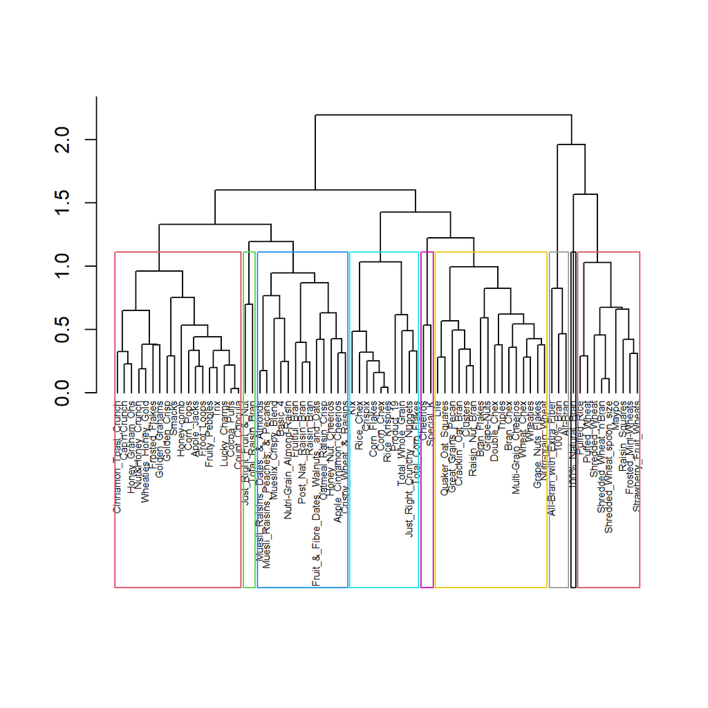

```r
hc2<- hclust(d.norm,method="complete") # complete linkage
plot(hc2,hang=-1,ann= FALSE,cex=0.5)
rect.hclust(hc2, k = 9, border=2:9)
```

The first plot displays the results for the single linkage method and the second one for the complete method. The latter seems to yield clearer representation. The 9 optimal clusters we draw on the graph appear more equilibrated for the complete method. We count 9 clusters for the complete method, and 9 for the single method.

### Comparison of the two methods:

### Interpretability

The *agglomerative coefficient* is compute by taking the ratio of the number of pairs of points that are in the same cluster to the total number of pairs of points. It tells us how “strong” the clusters are, meaning the data is well-grouped.

```r
methods_used<- c ("single", "complete") # vector of methods used
names(methods_used) <- c("single", "complete")  # names for printing

#compute agglomerative coefficient (closer to 1 the stronger the cluster)
ac <- function(x) {
  agnes(normal.df, method = x)$ac
}

sapply(methods_used,ac) # apply function to our data set for both methods
```

```
##    single  complete
## 0.5937582 0.8378129
```

The stronger cluster is the one using complete linkage, the value is closer to 1. This translates into well-grouped data.

### Optimal number of clusters:

we use the gap statistic, which compares the total intra-cluster variation for different values of k (number of clusters). (From clusGap documentation)For each number of clusters K, it compares log(W(k)) with E^*[(W(k))], the latter is defined via bootstrap. Which is why we have the B argument, being the number of samples formed.

source:(https://www.statology.org/hierarchical-clustering-in-r/)

```r
set.seed
```

[output not shown]

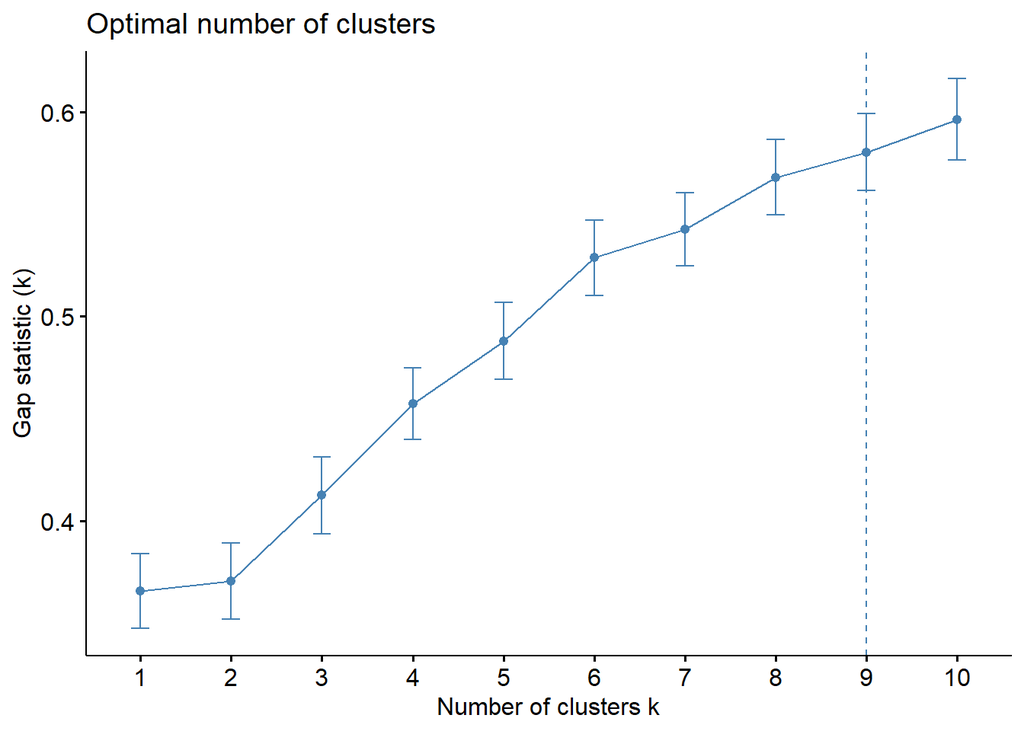

```r
gap_stat <- clusGap(normal.df, FUN = hcut, nstart = 25, K.max = 10, B = 50)
# we consider 10 clusters maximum
# 50 bootstrap samples

#produce plot of clusters vs. gap statistic
fviz_gap_stat(gap_stat)
```

The supposed optimal number is 9 clusters, we group variables into 9 clusters.

```r
single.cut <- cutree(hc1, k=9) # cut the dendrogram to 9 clusters
complete.cut <- cutree(hc2,k=9)

table(single.cut)# number of observation in each cluster
```

```
## single.cut
##  1  2  3  4  5  6  7  8  9
##  2  1  1 58  2  5  2  2  1
```

```r
table(complete.cut)
```

```
## complete.cut
##  1  2  3  4  5  6  7  8  9
##  3  1 13 18 16  2 10  9  2
```

We observe the output for the number of observations in each of the clusters that the 2 methods produce. So single linkage seems to cluster together 58 datapoints in the 4th cluster. Whilst the complete linkage methods seems to spread out the grouping more. Given that we have previously seen that the Agglomerative Coefficient was closer to 1 for the complete method. It seems like the clustering performed by the single linkage method is “rushed”. We have also mentioned that said approach tends to cluster together data points that are not actually close to one another, due to “chains” of points in proximity of each-other.

```r
# Append cluster labels to normal.df dataset
s_data<- cbind(normal.df, cluster= single.cut)
c_data<- cbind(normal.df, cluster= complete.cut)

#compute the means of the variables in each cluster
#cluster centroids
centroids_s<-data.frame(aggregate(s_data, by=list(cluster=s_data$cluster), mean))
centroids_c<-data.frame(aggregate(c_data, by=list(cluster=c_data$cluster), mean))

centroids_s<- centroids_s[,-14] # avoid redundancy in the table
centroids_c<- centroids_c[,-14]

kable(centroids_s, row.names = F)%>% kable_paper("hover", full_width = T)%>% add_header_above(c("Single Linkage"=13)) #built table
```

| Single Linkage cluster | Single Linkage calories | Single Linkage protein | Single Linkage fat | Single Linkage sodium | Single Linkage fiber | Single Linkage carbo | Single Linkage sugars | Single Linkage potass | Single Linkage vitamins | Single Linkage weight | Single Linkage cups | Single Linkage rating |
| --- | --- | --- | --- | --- | --- | --- | --- | --- | --- | --- | --- | --- |
| 1 | 0.1818182 | 0.6000000 | 0.2000000 | 0.6093750 | 0.6785714 | 0.0555556 | 0.3666667 | 0.9047619 | 0.250000 | 0.5000000 | 0.0640000 | 0.6062667 |
| 2 | 0.6363636 | 0.4000000 | 1.0000000 | 0.0468750 | 0.1428571 | 0.1666667 | 0.5333333 | 0.3809524 | 0.000000 | 0.5000000 | 0.6000000 | 0.2106846 |
| 3 | 0.0000000 | 0.6000000 | 0.0000000 | 0.4375000 | 1.0000000 | 0.1666667 | 0.0000000 | 1.0000000 | 0.250000 | 0.5000000 | 0.2000000 | 1.0000000 |
| 4 | 0.5313480 | 0.2551724 | 0.1862069 | 0.5094289 | 0.1293103 | 0.5507663 | 0.5091954 | 0.2307061 | 0.237069 | 0.5427586 | 0.4433103 | 0.2975994 |
| 5 | 0.5454545 | 1.0000000 | 0.2000000 | 0.8125000 | 0.1071429 | 0.6388889 | 0.1333333 | 0.2063492 | 0.250000 | 0.5000000 | 0.7000000 | 0.4481151 |
| 6 | 0.5636364 | 0.3200000 | 0.1600000 | 0.6625000 | 0.1000000 | 0.7666667 | 0.3200000 | 0.1714286 | 1.000000 | 0.5600000 | 0.5600000 | 0.2901932 |
| 7 | 0.9090909 | 0.6000000 | 0.6000000 | 0.3828125 | 0.2142857 | 0.6111111 | 0.7333333 | 0.4920635 | 0.250000 | 0.5000000 | 0.6000000 | 0.2325533 |
| 8 | 0.0000000 | 0.1000000 | 0.0000000 | 0.0000000 | 0.0357143 | 0.3611111 | 0.0000000 | 0.0555556 | 0.000000 | 0.0000000 | 0.6000000 | 0.5793925 |
| 9 | 0.8181818 | 0.4000000 | 0.2000000 | 0.5937500 | 0.2857143 | 0.5555556 | 0.9333333 | 0.6825397 | 1.000000 | 1.0000000 | 0.6000000 | 0.1394349 |

```r
kable(centroids_c, row.names = F)%>% kable_paper("hover", full_width = T)%>% add_header_above(c("Complete Linkage"=13)) #built table
```

| Complete Linkage cluster | Complete Linkage calories | Complete Linkage protein | Complete Linkage fat | Complete Linkage sodium | Complete Linkage fiber | Complete Linkage carbo | Complete Linkage sugars | Complete Linkage potass | Complete Linkage vitamins | Complete Linkage weight | Complete Linkage cups | Complete Linkage rating |
| --- | --- | --- | --- | --- | --- | --- | --- | --- | --- | --- | --- | --- |
| 1 | 0.1212121 | 0.6000000 | 0.1333333 | 0.5520833 | 0.7857143 | 0.0925926 | 0.2444444 | 0.9365079 | 0.2500000 | 0.5000000 | 0.1093333 | 0.7375111 |
| 2 | 0.6363636 | 0.4000000 | 1.0000000 | 0.0468750 | 0.1428571 | 0.1666667 | 0.5333333 | 0.3809524 | 0.0000000 | 0.5000000 | 0.6000000 | 0.2106846 |
| 3 | 0.7062937 | 0.4000000 | 0.3384615 | 0.5709135 | 0.2280220 | 0.5149573 | 0.7076923 | 0.4456654 | 0.2500000 | 0.7038462 | 0.3907692 | 0.2348550 |
| 4 | 0.5606061 | 0.0777778 | 0.1888889 | 0.5156250 | 0.0277778 | 0.4259259 | 0.7814815 | 0.0784832 | 0.2500000 | 0.5000000 | 0.5168889 | 0.1324267 |
| 5 | 0.4715909 | 0.3750000 | 0.2375000 | 0.5390625 | 0.1897321 | 0.5503472 | 0.3291667 | 0.2986111 | 0.2500000 | 0.5000000 | 0.3320000 | 0.3840811 |
| 6 | 0.5454545 | 1.0000000 | 0.2000000 | 0.8125000 | 0.1071429 | 0.6388889 | 0.1333333 | 0.2063492 | 0.2500000 | 0.5000000 | 0.7000000 | 0.4481151 |
| 7 | 0.5181818 | 0.2200000 | 0.0800000 | 0.7718750 | 0.0500000 | 0.8555556 | 0.2066667 | 0.0936508 | 0.5500000 | 0.5000000 | 0.6504000 | 0.3160124 |
| 8 | 0.2929293 | 0.2888889 | 0.0222222 | 0.0052083 | 0.1507937 | 0.5740741 | 0.1555556 | 0.2398589 | 0.1111111 | 0.3700000 | 0.4791111 | 0.5944267 |
| 9 | 0.8181818 | 0.4000000 | 0.2000000 | 0.5625000 | 0.2142857 | 0.6944444 | 0.7666667 | 0.4682540 | 1.0000000 | 0.9000000 | 0.5000000 | 0.1915002 |

These tables report the means that every variable takes within each of the 9 clusters. Just as an example the mean for carbs in cluster 4 is 0.426.

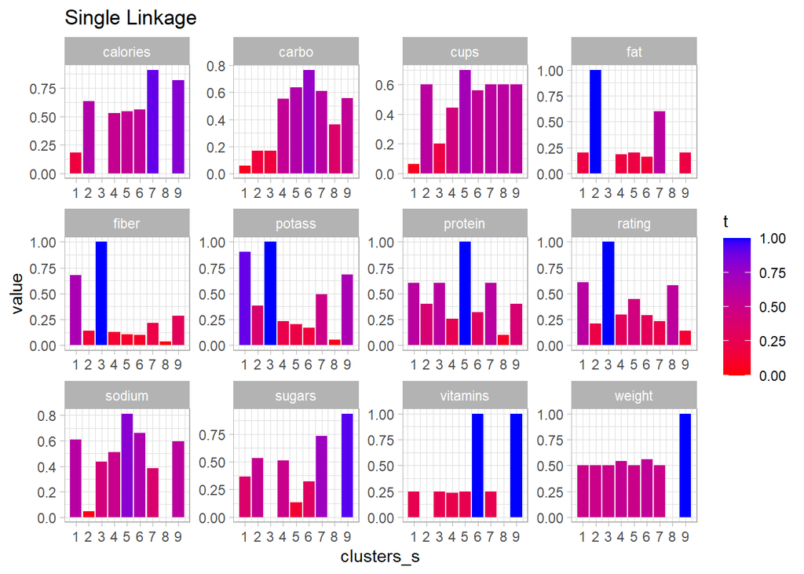

```r
# Plot means of variables in clusters in the 2 dendrograms:

single_means<-centroids_s%>%select(2:13)%>% gather() #group the data by clusters
clusters_s<-as.data.frame(table(single_means$key))$Freq
single_means$clusters_s<- 1:clusters_s # enumerate clusters in the reshaped data

# plot of means of every variable, for the 9 clusters achieved from single linkage
ggplot(single_means)+
  facet_wrap(~ key, scales = "free") +
  geom_col(aes(x=clusters_s, y=value,fill=value)) +
  theme_light()+
  scale_fill_gradient("t", low = "red", high = "blue")+
  scale_x_continuous(breaks=1:9)+ ggtitle("Single Linkage")
```

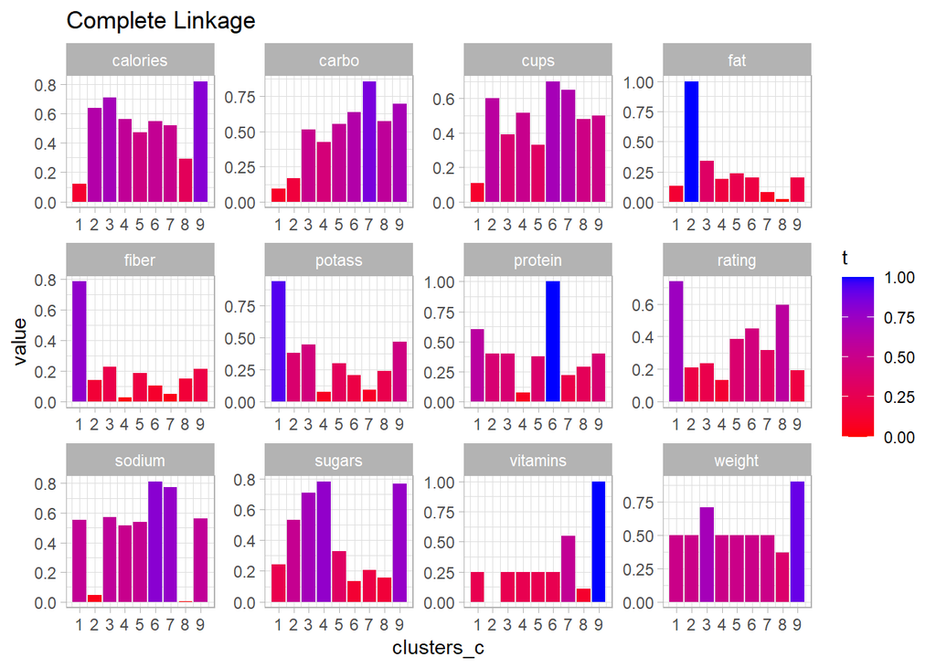

```r
complete_means<-centroids_c%>%select(2:13)%>% gather()
clusters_c<-as.data.frame(table(complete_means$key))$Freq
complete_means$clusters_c<- 1:clusters_c # reshaped data

# plot of means of every variable, for the 9 clusters achieved from complete linkage
ggplot(complete_means)+
  facet_wrap(~ key, scales = "free") +
  geom_col(aes(x=clusters_c, y=value,fill=value)) +
  theme_light()+
  scale_fill_gradient("t", low = "red", high = "blue")+
  scale_x_continuous(breaks=1:9) + ggtitle("Complete Linkage")
```

### Cluster Stability:

One way to test for cluster stability is to partition the data as suggested by the book and judge assignation to clusters.

```r
# rename the rows
row.names(df2)<- df$name
head(row.names(df2))
```

```
## [1] "100%_Bran"                 "100%_Natural_Bran"
## [3] "All-Bran"                  "All-Bran_with_Extra_Fiber"
## [5] "Apple_Cinnamon_Cheerios"   "Apple_Jacks"
```

```r
set.seed(1234) # to randomly select the records that will make up the samples, and get the same samples when we re-run the code
training<- sample(row.names(df2), 0.6*dim(df2)[1]) # 60% of records makeup the training set
validation <- setdiff(row.names(df2), training ) # 40% the validation set, all records not previously sorted in the training set
train.df<- df2[training,] #in data.frame format
valid.df<- df2[validation,] #in data.frame format

values_2 <- preProcess(train.df, method=c("range")) # pre-processing on training set
train.normal <- data.frame(predict(values_2, train.df))
valid.normal <- data.frame(predict(values_2, valid.df))
```

Hierarchical clustering cannot label new instances on the “constructed” model.As an approach itself it is not very stable,the clustering of a training and validation set would be very different in centroids and members. source:( https://stackoverflow.com/questions/21064315/how-do-i-predict-new-datas-cluster-after-clustering-training-data)

We will keep the optimal k=9 we obtained from the gap statistic computed over the entire dataset, if we were to try and yield an optimal k value from the training set the gap statistic would yield k=1, possibly for the reduced size of the sample.

The linked page, suggests to use the K-nearest neighbour method to classify the validation data points, we will adopt this method, to then compare performance of single and complete linkage approaches. We will do this by simply comparing the plots.

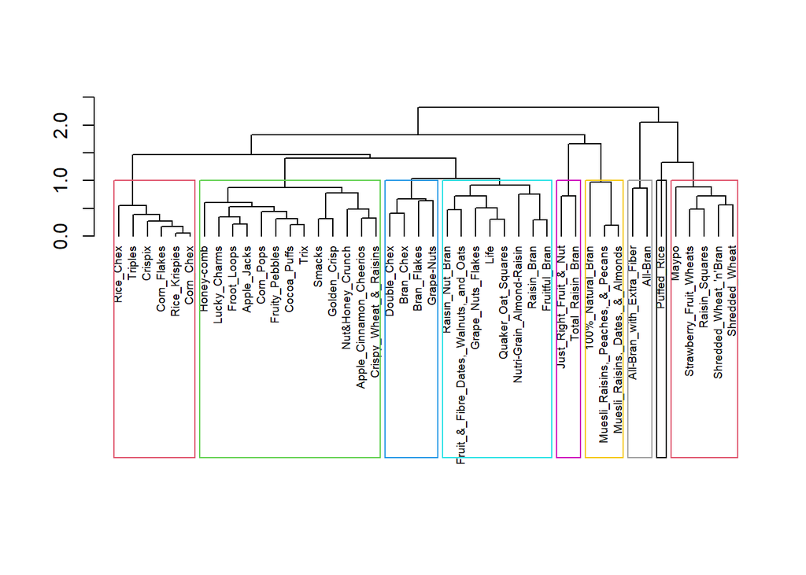

```r
# Complete linkage

dist_stability_train <- dist(train.normal, method = "euclidean") # Euclidian distances
hc1_train <- hclust(dist_stability_train , method = "complete")  # complete method
plot(hc1_train, hang = -1, ann = FALSE, cex=0.6)
rect.hclust(hc1_train, k = 9, border=2:9)
```

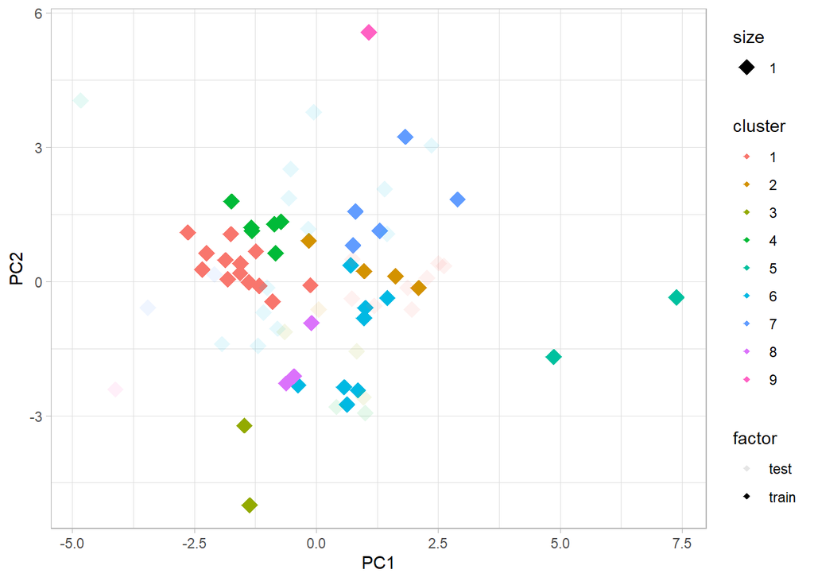

```r
comp_cut_train <- cutree(hc1_train, k=9) # cut at 9 clusters

knnClust <- knn(train = train.normal, test = valid.normal , k = 1, cl = comp_cut_train) # use knn to classify validation data

# clustering of training set
trainc <- data.frame(prcomp(train.normal, scale. = T)$x[,1:2], cluster = as.factor(comp_cut_train), factor = "train")

# clustering of valid set
valc <- data.frame(prcomp(valid.normal, scale. = T)$x[,1:2], cluster = as.factor(knnClust), factor = "test")

#prcomp function performs principal components analysis on the datasets


pca <- as.data.frame(rbind(trainc,valc)) # build data.frame to plot

ggplot(pca, aes(x = PC1, y = PC2, color = cluster, size = 1, alpha =factor)) +
  geom_point(shape = 18) + theme_light()
```

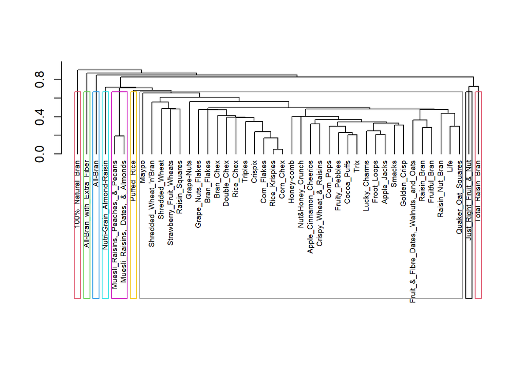

```r
# Single linkage

hc2_train <- hclust(dist_stability_train , method = "single")  # complete method
plot(hc2_train, hang = -1, ann = FALSE, cex=0.6)# plot clustering
rect.hclust(hc2_train, k = 9, border=2:9)
```

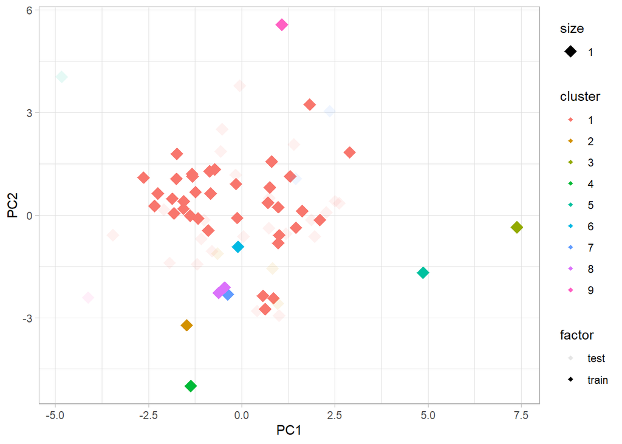

```r
single_cut_train <- cutree(hc2_train, k=9) # cut at 9 clusters

knnClust_single <- knn(train = train.normal, test = valid.normal , k = 1, cl = single_cut_train) # use knn to classify validation data

# clustering of training set
trains <- data.frame(prcomp(train.normal, scale. = T)$x[,1:2], cluster = as.factor(single_cut_train), factor = "train")
# clustering of valid set
vals <- data.frame(prcomp(valid.normal, scale. = T)$x[,1:2], cluster = as.factor(knnClust_single), factor = "test")

pca_single <- as.data.frame(rbind(trains,vals)) # build data.frame to plot

ggplot(pca_single, aes(x = PC1, y = PC2, color = cluster, size = 1, alpha =factor)) +
  geom_point(shape = 18) + theme_light()
```

Firstly, we observe that “rushed” clustering that we saw at the start of the exercise with the single linkage approach. By looking at the more transparent points and therefore the “stability” of the clustering we deduce that the “variation” in clustering is, at least *visually*, higher for the single linkage approach. So far, everthing points to the conclusion that the single linkage approach is not the optimal one. The clusters are not high in strength, there is great disparity in the *agglomerative coefficients* the 2 methods produce. Moreover, it produces averages for some varibales in cluster 8 that seem to point to innaccurate grouping, and making the clustering not as useful.

The minimal distance measuring is not the best choice.

### Which methods lead to the most insightful and meaning clusters?

### 15.3.b

Given what we saw previously, the *complete* method seems to do a better results in this case. When we look at the first 2 plottings of the clusters we made for `hc1` and `hc2` and the results of our `cutree` function the complete method gives more solid results. The single method clusters many members in the same 4th cluster.

### Which k would you use for your method of choice? What distance is used for this cut off?

### 15.3.c

Reporting our first observation the best method is complete linkage. It displays 9 clusters “above” the cut-off which is the the number suggested by our search for the optimal k. The distance is below 1.25.

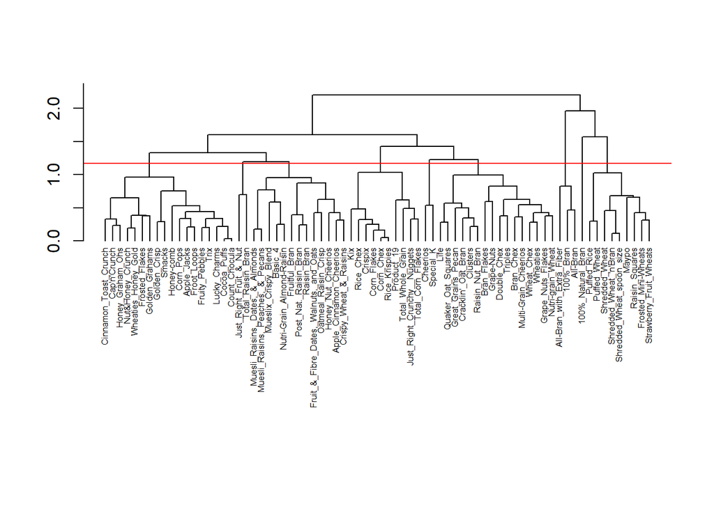

```r
plot(hc2,hang=-1,ann= FALSE,cex=0.5)
abline(h = 1.17, col = "red")
```

### 15.3.d

The data should be normalised, hierarchical clustering operate with Euclidian distances, it is very susceptible to out-liers.. Nutritional values are not all measured with the same metrics, and we are operating with an heterogeneous data set to begin with

To answer this we refer back to the table we built for the averages of the complete method. We define `fat`,`sodium`,`sugars` as the nutritional values that we would like to keep low. There are some variables that will not be taken into consideration, simply because they cannot be deemed healthy/unhealthy simply by taking average quantities into consideration.

We do not consider calories, because these cereals need to be nutritious, they will be served to people in development age and who expend a lot of energies during the day.

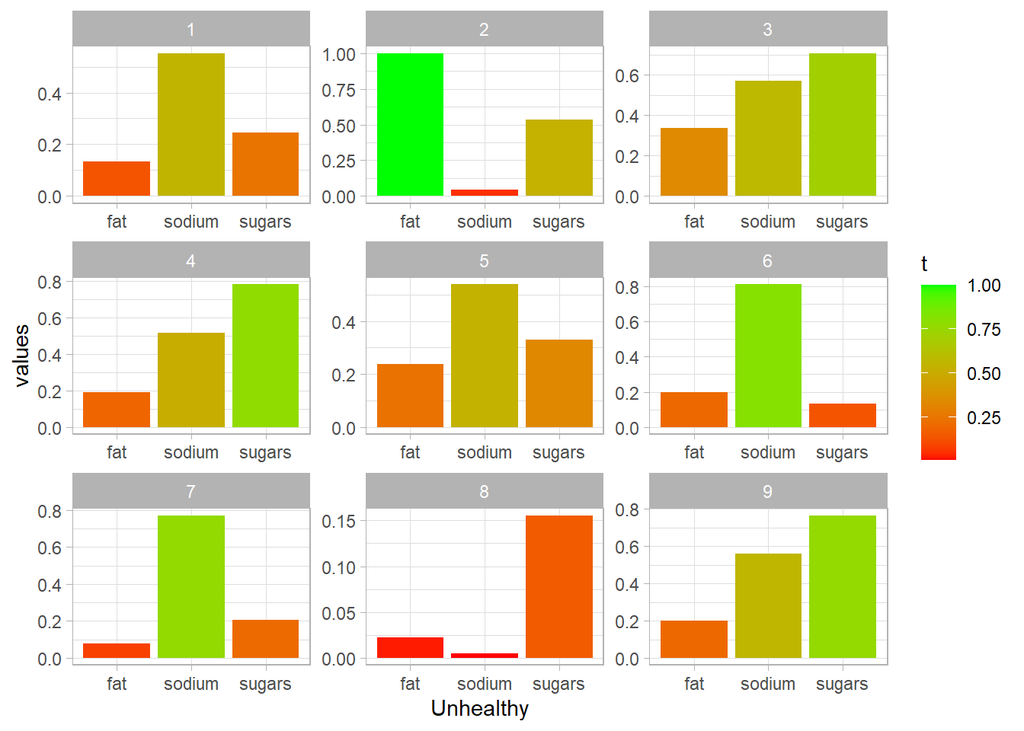

```r
# we reshape eh data so that we can plot for every cluster the averages of these 3 nutrients
bad<-centroids_c%>%select(4,5,8) %>% gather("Unhealthy","values",factor_key = TRUE)
bad$bad_c<- 1:9 # reshaped data

ggplot(bad)+
  facet_wrap(~ bad_c, scales = "free") +
  geom_col(aes(x=Unhealthy, y=values,fill=values)) +
  theme_light()+
  scale_fill_gradient("t", low = "red", high = "green")
```

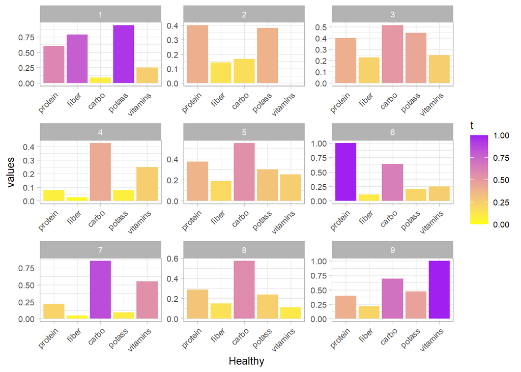

```r
# Heathy features
good<-centroids_c%>%select(3,6,7,9,10) %>% gather("Healthy","values",factor_key = TRUE)
good$good_c<- 1:9 # reshaped data

ggplot(good)+
  facet_wrap(~ good_c, scales = "free") +
  geom_col(aes(x=Healthy, y=values,fill=values)) +
  theme_light()+
  theme(text = element_text(size = 10), axis.text.x = element_text(angle=45, hjust=1))+
  scale_fill_gradient("t", low = "yellow", high = "purple")
```